# Model 3 - Response to SLE treatment

DATA3888 · Biomed9

Author

Jillian

Published

April 30, 2026

## 1 Dataset

This analysis uses **GSE224705**, a human whole-blood gene expression dataset focused on **lupus nephritis treatment response**. While the samples contain **RMA-normalised microarray** expression values. The biological aim is to understand why some patients do **not respond** to common therapies such as mycophenolate mofetil (MMF), azathioprine (AZA), hydroxychloroquine (HC). The GEO summary says the cohort contains longitudinal gene-expression and clinical data from responders and non-responders, with response defined over time using **SRI-4 scores**.

The accession page is available at https://www.ncbi.nlm.nih.gov/geo/query/acc.cgi?acc=GSE224705.

## 2 Research question

How do SLE patients respond to specific treatments?

## 3 Setup

```r
library(GEOquery)
library(Biobase)
library(ggplot2)
library(randomForest)
library(Boruta)
library(limma)
library(glmnet)
```

## 4 Loading the data

The data for this analysis are obtained from the Gene Expression Omnibus (GEO) accession GSE224705.

Code chunk `load-geo-metadata` retrieves the GEO dataset and loads sample metadata including both expression labels and clinical variables as well as the expression matrix. The dataset has 448 samples, and 54715 probes for each sample.

```r
gse <- getGEO("GSE224705", GSEMatrix = TRUE)
sample_metadata <- pData(gse[[1]])
feature_data <- fData(gse[[1]])
exprs_mat <- exprs(gse[[1]])
dim(exprs_mat)
```

```
[1] 54715   448
```

## 5 Exploratory data analysis

### 5.1 Important metadata fields and outcome variable

Key fields include:

- `title`: patient id + no. visit + response. E.g., Pat_24_visit1_NO_response
- `patient_id:ch1`
- `diagnosis:ch1`: SLE or Healthy
- `Sex:ch1`: sex
- `race:ch1`: race
- `age_onset:ch1`: age_onset
- `drug_group:ch1`: MMF, PHC, AZA, HC
- `mmf_or_aza_dosis:ch1`: MMF/AZA dose, depending on the drug group
- `sledai:ch1`: SLEDAI (Systemic Lupus Erythematosus Disease Activity Index); disease activity score
- `summary_disease_activity(act):ch1`: a simplified/coded disease-activity category (1/2/3)
- **Outcome variable** `sri4_response:ch1`: response to drug or not (`YES`/`NO`)

Healthy controls exist; Clinical fields mostly marked as `NA` or `Data_not_available`; No drug given. Less useful for modelling clinical covariates.

```r
sample_metadata[15:25, ]
```

|  | title | geo_accession | status | submission_date | last_update_date | type | channel_count | source_name_ch1 | organism_ch1 | characteristics_ch1 | characteristics_ch1.1 | characteristics_ch1.2 | characteristics_ch1.3 | characteristics_ch1.4 | characteristics_ch1.5 | characteristics_ch1.6 | characteristics_ch1.7 | characteristics_ch1.8 | characteristics_ch1.9 | characteristics_ch1.10 | characteristics_ch1.11 | characteristics_ch1.12 | characteristics_ch1.13 | characteristics_ch1.14 | characteristics_ch1.15 | characteristics_ch1.16 | treatment_protocol_ch1 | growth_protocol_ch1 | molecule_ch1 | … |
| --- | --- | --- | --- | --- | --- | --- | --- | --- | --- | --- | --- | --- | --- | --- | --- | --- | --- | --- | --- | --- | --- | --- | --- | --- | --- | --- | --- | --- | --- | --- |
| GSM7986642 | Healthy15 | GSM7986642 | Public on Dec 21 2023 | Dec 20 2023 | Dec 21 2023 | RNA | 1 | Healthy 15 | Homo sapiens | tissue: Whole Blood | patient_id: Healthy15 | diagnosis: Healthy | days_from_first_visit: 0 | Sex: Data_not_available | race: Data_not_available | age_onset: Data_not_available | drug_group: NA | sri4_response: NA | sledai: NA | pga: NA | summary_disease_activity(act): NA | protein_creatinine_ratio_urine_(mg/g): NA | mmf_or_aza_dosis: NA | prednisone_dosis: NA | asa_dosis: NA | plaquenil: NA | Standard | Whole Blood samples in collected fom PAXgene tubes | total RNA | … |
| GSM7986643 | Healthy16 | GSM7986643 | Public on Dec 21 2023 | Dec 20 2023 | Dec 21 2023 | RNA | 1 | Healthy 16 | Homo sapiens | tissue: Whole Blood | patient_id: Healthy16 | diagnosis: Healthy | days_from_first_visit: 0 | Sex: Data_not_available | race: Data_not_available | age_onset: Data_not_available | drug_group: NA | sri4_response: NA | sledai: NA | pga: NA | summary_disease_activity(act): NA | protein_creatinine_ratio_urine_(mg/g): NA | mmf_or_aza_dosis: NA | prednisone_dosis: NA | asa_dosis: NA | plaquenil: NA | Standard | Whole Blood samples in collected fom PAXgene tubes | total RNA | … |
| GSM7986644 | Healthy17 | GSM7986644 | Public on Dec 21 2023 | Dec 20 2023 | Dec 21 2023 | RNA | 1 | Healthy 17 | Homo sapiens | tissue: Whole Blood | patient_id: Healthy17 | diagnosis: Healthy | days_from_first_visit: 0 | Sex: Data_not_available | race: Data_not_available | age_onset: Data_not_available | drug_group: NA | sri4_response: NA | sledai: NA | pga: NA | summary_disease_activity(act): NA | protein_creatinine_ratio_urine_(mg/g): NA | mmf_or_aza_dosis: NA | prednisone_dosis: NA | asa_dosis: NA | plaquenil: NA | Standard | Whole Blood samples in collected fom PAXgene tubes | total RNA | … |
| GSM7986645 | Healthy18 | GSM7986645 | Public on Dec 21 2023 | Dec 20 2023 | Dec 21 2023 | RNA | 1 | Healthy 18 | Homo sapiens | tissue: Whole Blood | patient_id: Healthy18 | diagnosis: Healthy | days_from_first_visit: 0 | Sex: Data_not_available | race: Data_not_available | age_onset: Data_not_available | drug_group: NA | sri4_response: NA | sledai: NA | pga: NA | summary_disease_activity(act): NA | protein_creatinine_ratio_urine_(mg/g): NA | mmf_or_aza_dosis: NA | prednisone_dosis: NA | asa_dosis: NA | plaquenil: NA | Standard | Whole Blood samples in collected fom PAXgene tubes | total RNA | … |
| GSM7986646 | Healthy19 | GSM7986646 | Public on Dec 21 2023 | Dec 20 2023 | Dec 21 2023 | RNA | 1 | Healthy 19 | Homo sapiens | tissue: Whole Blood | patient_id: Healthy19 | diagnosis: Healthy | days_from_first_visit: 0 | Sex: Data_not_available | race: Data_not_available | age_onset: Data_not_available | drug_group: NA | sri4_response: NA | sledai: NA | pga: NA | summary_disease_activity(act): NA | protein_creatinine_ratio_urine_(mg/g): NA | mmf_or_aza_dosis: NA | prednisone_dosis: NA | asa_dosis: NA | plaquenil: NA | Standard | Whole Blood samples in collected fom PAXgene tubes | total RNA | … |
| GSM7986647 | Healthy20 | GSM7986647 | Public on Dec 21 2023 | Dec 20 2023 | Dec 21 2023 | RNA | 1 | Healthy 20 | Homo sapiens | tissue: Whole Blood | patient_id: Healthy20 | diagnosis: Healthy | days_from_first_visit: 0 | Sex: Data_not_available | race: Data_not_available | age_onset: Data_not_available | drug_group: NA | sri4_response: NA | sledai: NA | pga: NA | summary_disease_activity(act): NA | protein_creatinine_ratio_urine_(mg/g): NA | mmf_or_aza_dosis: NA | prednisone_dosis: NA | asa_dosis: NA | plaquenil: NA | Standard | Whole Blood samples in collected fom PAXgene tubes | total RNA | … |
| GSM7986648 | Pat_24_visit1_NO_response | GSM7986648 | Public on Dec 21 2023 | Dec 20 2023 | Dec 21 2023 | RNA | 1 | SLE, Patient 24, visit1, response: NO, MMF | Homo sapiens | tissue: Whole Blood | patient_id: 24 | diagnosis: SLE | days_from_first_visit: 0 | Sex: Female | race: B | age_onset: 18.71409029 | drug_group: MMF | sri4_response: NO | sledai: 4 | pga: 2.5 | summary_disease_activity(act): 2 | protein_creatinine_ratio_urine_(mg/g): 8.22 | mmf_or_aza_dosis: 0 | prednisone_dosis: 40 | asa_dosis: 81 | plaquenil: 1 | Standard | Whole Blood samples in collected fom PAXgene tubes | total RNA | … |
| GSM7986649 | Pat_24_visit2_NO_response | GSM7986649 | Public on Dec 21 2023 | Dec 20 2023 | Dec 21 2023 | RNA | 1 | SLE, Patient 24, visit2, response: NO, MMF | Homo sapiens | tissue: Whole Blood | patient_id: 24 | diagnosis: SLE | days_from_first_visit: 52 | Sex: Female | race: B | age_onset: 18.71409029 | drug_group: MMF | sri4_response: NO | sledai: 0 | pga: 1.8 | summary_disease_activity(act): 1 | protein_creatinine_ratio_urine_(mg/g): 0.93 | mmf_or_aza_dosis: 0 | prednisone_dosis: 40 | asa_dosis: 81 | plaquenil: 1 | Standard | Whole Blood samples in collected fom PAXgene tubes | total RNA | … |
| GSM7986650 | Pat_24_visit3_NO_response | GSM7986650 | Public on Dec 21 2023 | Dec 20 2023 | Dec 21 2023 | RNA | 1 | SLE, Patient 24, visit3, response: NO, MMF | Homo sapiens | tissue: Whole Blood | patient_id: 24 | diagnosis: SLE | days_from_first_visit: 82 | Sex: Female | race: B | age_onset: 18.71409029 | drug_group: MMF | sri4_response: NO | sledai: 8 | pga: 2.5 | summary_disease_activity(act): 3 | protein_creatinine_ratio_urine_(mg/g): 2.57 | mmf_or_aza_dosis: 0 | prednisone_dosis: 40 | asa_dosis: 0 | plaquenil: 1 | Standard | Whole Blood samples in collected fom PAXgene tubes | total RNA | … |
| GSM7986651 | Pat_24_visit4_NO_response | GSM7986651 | Public on Dec 21 2023 | Dec 20 2023 | Dec 21 2023 | RNA | 1 | SLE, Patient 24, visit4, response: NO, MMF | Homo sapiens | tissue: Whole Blood | patient_id: 24 | diagnosis: SLE | days_from_first_visit: 124 | Sex: Female | race: B | age_onset: 18.71409029 | drug_group: MMF | sri4_response: NO | sledai: 0 | pga: 1.8 | summary_disease_activity(act): 1 | protein_creatinine_ratio_urine_(mg/g): 1.38 | mmf_or_aza_dosis: 2000 | prednisone_dosis: 0 | asa_dosis: 81 | plaquenil: 0 | Standard | Whole Blood samples in collected fom PAXgene tubes | total RNA | … |

[output cut: 1 more lines]

```r
unique(sample_metadata$`sri4_response:ch1`)
```

```
[1] "NA"  "NO"  "YES"
```

```r
unique(sample_metadata$`drug_group:ch1`)
```

```
[1] "NA"  "MMF" "PHC" "HC"  "AZA"
```

```r
unique(sample_metadata$`summary_disease_activity(act):ch1`)
```

```
[1] "NA" "2"  "1"  "3"
```

Code chunk `extract-outcome` derives the response outcome to treatment according to the `sri4_response:ch1` variable.

```r
table(sample_metadata$`sri4_response:ch1`)
```

```
 NA  NO YES
 20 128 300
```

The cohort comprises 300 SLE samples with response to treatment and 128 non-response samples, and 20 healthy controls. Healthy controls are not helpful to the treatment response question.

### 5.2 Excluding healthy controls

Code chunk `exclude-healthy` filters for SLE-only samples into `sample_metadata_sle`.

```r
sample_metadata_sle <- sample_metadata[sample_metadata$`diagnosis:ch1` == "SLE", ]
```

### 5.3 First visit patients

Code chunk `first-visit-only` reflects the design choice of using first-visit samples only. This avoids a major issue: later visits may already reflect treatment effect. For example, for samples with visit 2, 3, 4, some predictors may be partially caused by the treatment given previously, which makes the model less like a real pre-treatment risk calculator. With first-visit only, the left 163 samples remains sufficient for classification.

```r
sample_metadata_visit1 <- sample_metadata_sle[grep("visit1", sample_metadata_sle$title), ]
dim(sample_metadata_visit1)
```

```
[1] 163  66
```

### 5.4 Treatment response distribution

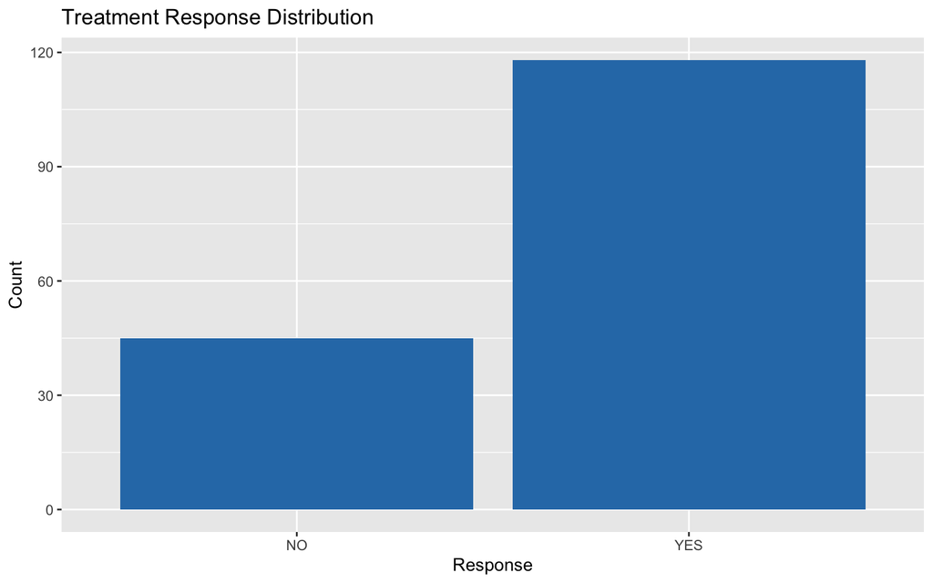

```r
ggplot(sample_metadata_visit1, aes(x = `sri4_response:ch1`)) +
  geom_bar(fill = "#2C7BB6") +
  labs(title = "Treatment Response Distribution",
       x = "Response",
       y = "Count")
```

### 5.5 Response by treatment

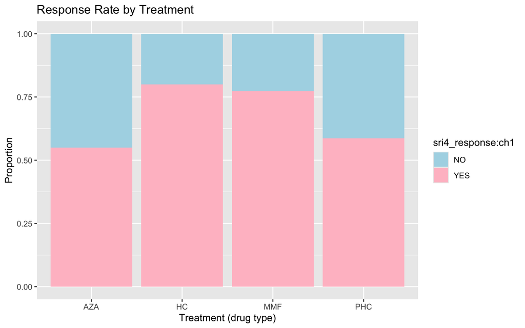

```r
ggplot(sample_metadata_visit1, aes(x = `drug_group:ch1`, fill = `sri4_response:ch1`)) +
  geom_bar(position = "fill") +
  labs(title = "Response Rate by Treatment",
       x = "Treatment (drug type)",
       y = "Proportion") +
  scale_fill_manual(values = c("lightblue", "pink"))
```

### 5.6 Distribution of expression values

Code chunk `exprs-filter` filters the expression matrix for first visit, SLE samples as the metadata.

```r
exprs_mat_visit1 <- exprs_mat[, rownames(sample_metadata_visit1)]
dim(exprs_mat_visit1)
```

```
[1] 54715   163
```

Code chunk `rpkm-range` summarises the empirical distribution across the full expression matrix.

```r
summary(as.vector(exprs_mat_visit1))
```

```
   Min. 1st Qu.  Median    Mean 3rd Qu.    Max.
 0.6191  2.8441  4.2197  4.6561  6.1230 14.0261
```

```r
quantile(as.vector(exprs_mat_visit1),
         probs = c(0.5, 0.9, 0.99, 0.999, 1))
```

```
      50%       90%       99%     99.9%      100%
 4.219725  7.894513 10.732932 12.316263 14.026109
```

Code chunk `exprs-sample-boxplots` the per-sample distribution of gene expression values as boxplots, with samples ordered and coloured by outcome. The boxplots prove that the expression values have been normalised, as mentioned by the dataset description.

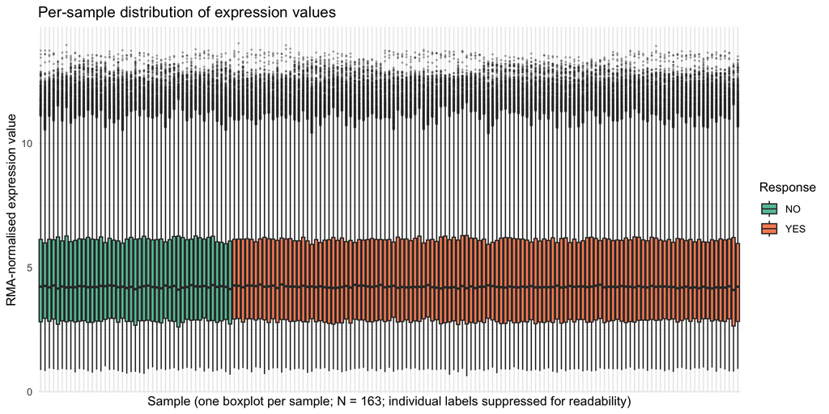

```r
response <- sample_metadata_visit1$`sri4_response:ch1`
response <- factor(sample_metadata_visit1$`sri4_response:ch1`,
                   levels = c("NO", "YES"))

sample_levels <- colnames(exprs_mat_visit1)[
  order(response, colnames(exprs_mat_visit1))
]

exprs_long <- data.frame(
  sample = factor(
    rep(colnames(exprs_mat_visit1), each = nrow(exprs_mat_visit1)),
    levels = sample_levels
  ),
  expression_value = as.vector(exprs_mat_visit1),
  outcome = rep(response, each = nrow(exprs_mat_visit1))
)

ggplot(exprs_long, aes(x = sample, y = expression_value, fill = outcome)) +
  geom_boxplot(outlier.size = 0.3, outlier.alpha = 0.3) +
  scale_fill_manual(values = c("NO" = "#66c2a5", "YES" = "#fc8d62")) +
  labs(x = "Sample (one boxplot per sample; N = 163; individual labels suppressed for readability)",
       y = "RMA-normalised expression value",
       fill = "Response",
       title = "Per-sample distribution of expression values") +
  theme_minimal() +
  theme(axis.text.x = element_blank(),
        axis.ticks.x = element_blank())
```

### 5.7 Probe filtering

Code chunk checks useful annotation columns, which include “Gene Symbol” and “Gene Title”.

```r
feature_data <- feature_data[rownames(exprs_mat_visit1), ]
colnames(feature_data)
```

```
 [1] "ID"                               "GB_ACC"
 [3] "SPOT_ID"                          "Species Scientific Name"
 [5] "Annotation Date"                  "Sequence Type"
 [7] "Sequence Source"                  "Target Description"
 [9] "Representative Public ID"         "Gene Title"
[11] "Gene Symbol"                      "ENTREZ_GENE_ID"
[13] "RefSeq Transcript ID"             "Gene Ontology Biological Process"
[15] "Gene Ontology Cellular Component" "Gene Ontology Molecular Function"
```

Code chunk `filter-unannotated-probes` removes probes with missing, empty, or placeholder gene symbols

```r
keep_gene <- !is.na(feature_data$`Gene Symbol`) &
  feature_data$`Gene Symbol` != "" &
  feature_data$`Gene Symbol` != "---"

exprs_gene_annotated <- exprs_mat_visit1[keep_gene, ]
feature_gene_annotated <- feature_data[keep_gene, ]

dim(exprs_gene_annotated)
```

```
[1] 41796   163
```

There exist Affymetrix control probes, which often start with `AFFX`. These are technical controls, not biological genes. Code chunk `filter-control-probes` filters out control probes to avoid these becoming predictors in the later models.

```r
probe_ids <- rownames(exprs_gene_annotated)

keep_non_control <- !grepl("^AFFX", probe_ids)

exprs_no_control <- exprs_gene_annotated[keep_non_control, ]
feature_gene_no_control <- feature_gene_annotated[keep_non_control, ]

dim(exprs_no_control)
```

```
[1] 41786   163
```

### 5.8 Collapse multiple probes per gene

Code chunk `collapse-multiple-probes` handles the issue where multiple probes still map to the same gene. Such probes are collapsed so each gene appears once.

```r
gene_symbol <- feature_gene_no_control$`Gene Symbol`

probe_var <- apply(exprs_no_control, 1, var, na.rm = TRUE)

probe_info <- data.frame(
  probe_id = rownames(exprs_no_control),
  gene_symbol = gene_symbol,
  probe_var = probe_var
)

# Keep highest-variance probe for each gene
probe_info <- probe_info[order(probe_info$gene_symbol, -probe_info$probe_var), ]

best_probe_per_gene <- probe_info[!duplicated(probe_info$gene_symbol), ]

exprs_mat_visit1_clean <- exprs_no_control[best_probe_per_gene$probe_id, ]

# Rename rows from probe IDs to gene symbols
rownames(exprs_mat_visit1_clean) <- best_probe_per_gene$gene_symbol

dim(exprs_mat_visit1_clean)
```

```
[1] 20741   163
```

### 5.9 Highly expressed probes

```r
gene_mean_expression <- sort(rowMeans(exprs_mat_visit1_clean), decreasing = TRUE)
head(gene_mean_expression, 10)
```

```
                                                                        ACTB
                                                                    12.73892
                                                                       RPS11
                                                                    12.70960
                                                                       RPL41
                                                                    12.62057
                                                               HBA1 /// HBA2
                                                                    12.59960
LOC100287887 /// RPL13A /// RPL13AP20 /// RPL13AP3 /// RPL13AP5 /// RPL13AP6
                                                                    12.51863
                                                            TMSB4X /// TMSL3
                                                                    12.45782
                                                                       RPL32
                                                                    12.45755
                                                                       UBA52
                                                                    12.41077
                                                                      TMSB10
                                                                    12.40552
                                                         EEF1A1 /// EEF1A1P9
                                                                    12.38919
```

### 5.10 Principal component analysis

Code chunk `pca-fit` performs a scaled principal component analysis on the cleaned expression matrix. The variance contributions of the first 10 components are reported.

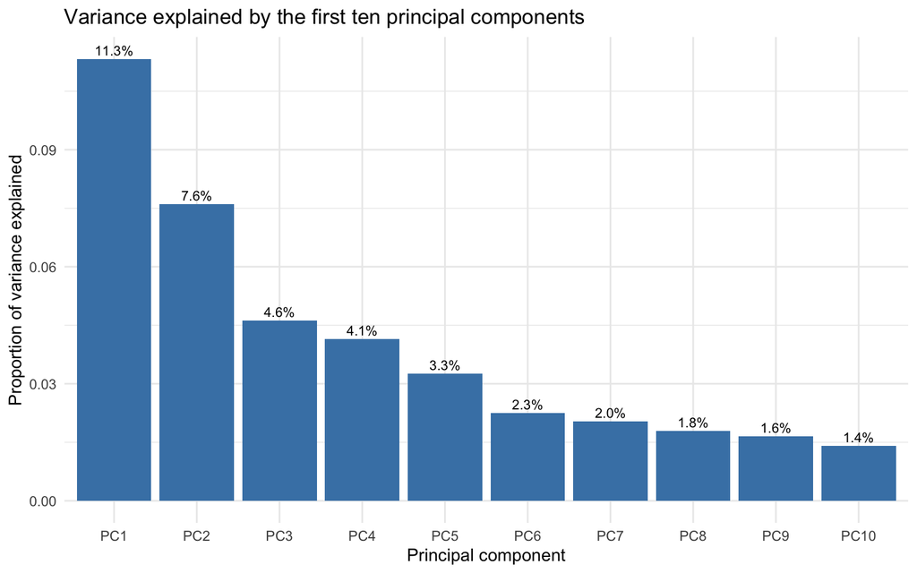

```r
pca_fit <- prcomp(t(exprs_mat_visit1_clean), center = TRUE, scale. = TRUE)

variance_explained <- summary(pca_fit)$importance["Proportion of Variance", 1:10]

scree_df <- data.frame(
  pc = factor(paste0("PC", 1:10), levels = paste0("PC", 1:10)),
  variance = as.numeric(variance_explained)
)

ggplot(scree_df, aes(x = pc, y = variance)) +
  geom_col(fill = "steelblue") +
  geom_text(aes(label = sprintf("%.1f%%", 100 * variance)),
            vjust = -0.4, size = 3) +
  labs(x = "Principal component", y = "Proportion of variance explained",
       title = "Variance explained by the first ten principal components") +
  theme_minimal()
```

Code chunk `pca-plot` projects each sample onto the first two principal components and colours the result by response outcome.

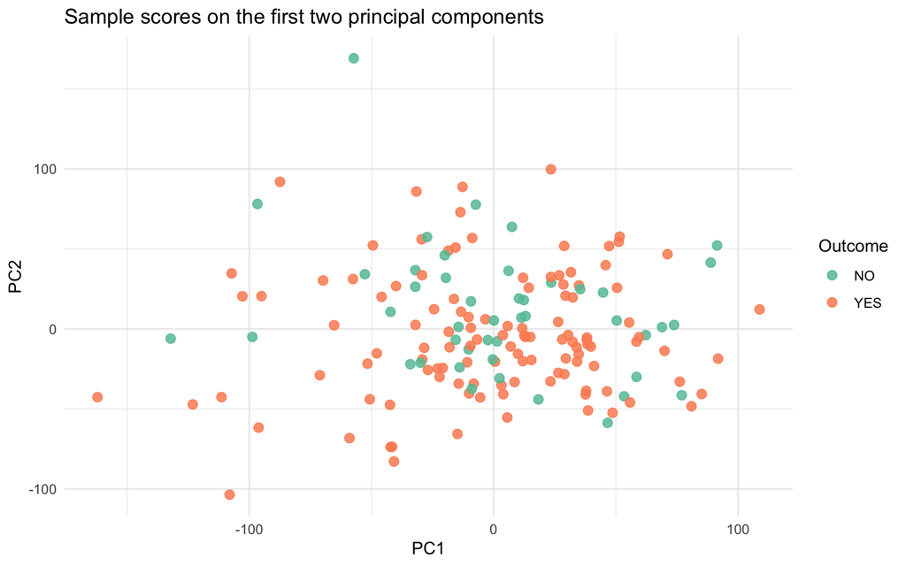

```r
pc_scores <- data.frame(
  PC1 = pca_fit$x[, 1],
  PC2 = pca_fit$x[, 2],
  outcome = sample_metadata_visit1$`sri4_response:ch1`
)

ggplot(pc_scores, aes(x = PC1, y = PC2, colour = outcome)) +
  geom_point(size = 2.5, alpha = 0.85) +
  scale_colour_manual(values = c("NO" = "#66c2a5", "YES" = "#fc8d62")) +
  labs(title = "Sample scores on the first two principal components",
       colour = "Outcome") +
  theme_minimal()
```

Code chunk `pca-loadings` reports the genes contributing most strongly to PC1 and PC2 by absolute loading. These are the genes that drive the dominant variance structure of the dataset and are natural candidates for inclusion in a downstream classifier.

```r
pc1_loadings <- pca_fit$rotation[, "PC1"]
pc2_loadings <- pca_fit$rotation[, "PC2"]

top_pc1_genes <- names(sort(abs(pc1_loadings), decreasing = TRUE))[1:15]
top_pc2_genes <- names(sort(abs(pc2_loadings), decreasing = TRUE))[1:15]

data.frame(
  pc1_gene    = top_pc1_genes,
  pc1_loading = round(pc1_loadings[top_pc1_genes], 4),
  pc2_gene    = top_pc2_genes,
  pc2_loading = round(pc2_loadings[top_pc2_genes], 4),
  row.names   = NULL
)
```

| pc1_gene | pc1_loading | pc2_gene | pc2_loading |
| --- | --- | --- | --- |
| FAM73A | 0.0178 | GLTSCR2 | -0.0219 |
| C9orf82 | 0.0175 | RPL18 | -0.0213 |
| FTSJD1 | 0.0174 | MLL | -0.0209 |
| TMX3 | 0.0173 | EIF3G | -0.0209 |
| PRKD3 | 0.0171 | PTEN | 0.0205 |
| SLC5A3 | 0.0170 | NDUFS6 | -0.0204 |
| ZC3H14 | 0.0170 | PITRM1 | -0.0203 |
| LIN7C | 0.0170 | CYBASC3 | -0.0203 |
| AKAP11 | 0.0169 | TECR | -0.0203 |
| PURA | 0.0168 | ITGB7 | -0.0202 |

[output cut: 5 more lines]

## 6 Feature Extraction

The pre-processed expression matrix contains 20741 genes for 163 samples. We now do a feature selection step before fitting any classifiers.

### 6.1 Pre-filtering low-expression and low-variance genes

Code chunk `feature-prefilter` discards genes that are expressed at near-baseline levels across the cohort (mean expression value < 1) and restricts the retained set to the 2,000 genes with the highest variance among those passing the expression threshold. Pre-filtering removes features that contribute only measurement noise and is required for the wrapper-based Boruta procedure to run in tractable time.

```r
gene_means <- rowMeans(exprs_mat_visit1_clean)
gene_variances <- apply(exprs_mat_visit1_clean, 1, var)

expressed_indices <- which(gene_means > 1)
variance_ranking <- order(gene_variances[expressed_indices], decreasing = TRUE)
selected_indices <- expressed_indices[variance_ranking[1:2000]]

exprs_mat_filtered <- exprs_mat_visit1_clean[selected_indices, ]
dim(exprs_mat_filtered)
```

```
[1] 2000  163
```

### 6.2 Random forest with Gini importance

Code chunk `rf-importance` fits a random forest of 500 trees to the pre-filtered matrix and ranks features by mean decrease in Gini impurity. Permutation importance remains the more rigorous choice for a final committed selection.

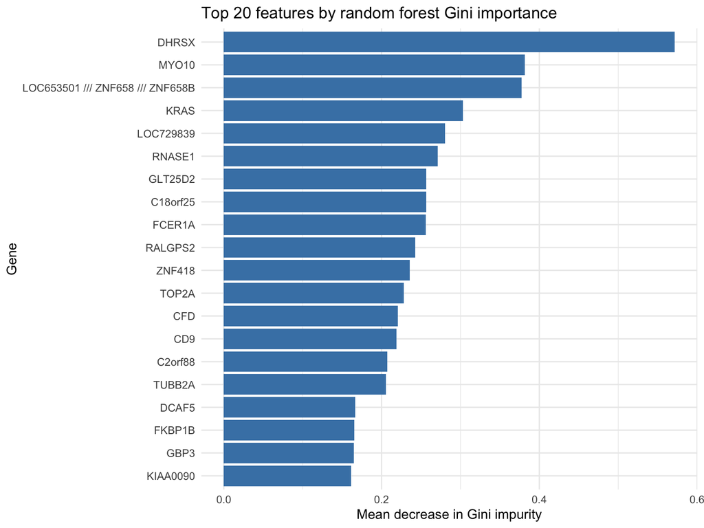

```r
set.seed(42)

response_outcome <- factor(
  sample_metadata_visit1$`sri4_response:ch1`,
  levels = c("NO", "YES"))

rf_fit <- randomForest(
  x = t(exprs_mat_filtered),
  y = response_outcome,
  ntree = 500,
  importance = TRUE
)

rf_gini <- importance(rf_fit, type = 2)
rf_ranking <- sort(rf_gini[, "MeanDecreaseGini"], decreasing = TRUE)

top_rf <- head(rf_ranking, 20)
top_rf_df <- data.frame(
  gene = factor(names(top_rf), levels = rev(names(top_rf))),
  gini_importance = as.numeric(top_rf)
)

ggplot(top_rf_df, aes(x = gini_importance, y = gene)) +
  geom_col(fill = "steelblue") +
  labs(x = "Mean decrease in Gini impurity",
       y = "Gene",
       title = "Top 20 features by random forest Gini importance") +
  theme_minimal()
```

### 6.3 Boruta

Code chunk `boruta-fit` runs Boruta with 100 iterations on the pre-filtered matrix.

```r
set.seed(42)
boruta_fit <- Boruta(
  x = t(exprs_mat_filtered),
  y = response_outcome,
  maxRuns = 100,
  doTrace = 0
)

table(boruta_fit$finalDecision)
```

```
Tentative Confirmed  Rejected
       11        10      1979
```

```r
confirmed_features <- getSelectedAttributes(boruta_fit, withTentative = FALSE)
length(confirmed_features)
```

```
[1] 10
```

```r
confirmed_features
```

```
 [1] "C2orf88"                          "CEACAM1"
 [3] "LOC729839"                        "LIMA1"
 [5] "DHRSX"                            "ZDHHC11"
 [7] "LOC653501.....ZNF658.....ZNF658B" "GBP3"
 [9] "MYO10"                            "KRAS"
```

Code chunk `overlap-genes` compares the top genes selected by both methods, and checks any overlaps.

```r
rf_gini_genes <- rf_ranking[1:20]
boruta_genes <- confirmed_features
overlap_genes <- intersect(rf_gini_genes, boruta_genes)
overlap_genes
```

```
character(0)
```

## 7 Modelling

Features unrelated to predictive performance need to be excluded from the modelling panel.

Need further research on the categories of those.

### 7.2 Cross-validation scheme

Code chunk `cv-folds` constructs a single set of stratified 5-fold assignments. The same fold structure is used for all three models.

```r
make_stratified_folds <- function(y, k, seed) {
  set.seed(seed)
  fold_id <- integer(length(y))
  for (cls in levels(y)) {
    cls_idx <- which(y == cls)
    fold_id[cls_idx] <- sample(rep(seq_len(k), length.out = length(cls_idx)))
  }
  fold_id
}

cv_folds <- make_stratified_folds(response_outcome, k = 5, seed = 42)
table(cv_folds, response_outcome)
```

```
        response_outcome
cv_folds NO YES
       1  9  24
       2  9  24
       3  9  24
       4  9  23
       5  9  23
```

### 7.3 Limma differential expression and class predictions

Code chunk `limma-de` fits a per-gene linear model (`outcome` as the only covariate) on the pre-filtered 2,000-gene matrix with empirical-Bayes shrinkage of variance estimates. The top 20 differentially expressed genes by adjusted p-value are reported as the regression output.

```r
limma_design <- model.matrix(~ response_outcome)
limma_fit <- eBayes(lmFit(exprs_mat_filtered, limma_design))

limma_top <- topTable(limma_fit, coef = 2, number = Inf,
                      adjust.method = "BH", sort.by = "P")
head(limma_top, 20)
```

|  | logFC | AveExpr | t | P.Value | adj.P.Val | B |
| --- | --- | --- | --- | --- | --- | --- |
| LOC729839 | -0.5603719 | 4.571186 | -4.458990 | 1.474502e-05 | 0.02949004 | 2.7840345 |
| MYO10 | -0.4430330 | 4.496585 | -4.065862 | 7.245773e-05 | 0.04289505 | 1.4041762 |
| RNASE1 | -0.4540416 | 5.213122 | -4.055496 | 7.545482e-05 | 0.04289505 | 1.3691722 |
| CFLAR | -0.4319577 | 4.217146 | -4.022536 | 8.579010e-05 | 0.04289505 | 1.2583534 |
| ZNF418 | 0.4323458 | 6.080814 | 3.935740 | 1.198520e-04 | 0.04794080 | 0.9700602 |
| DCAF5 | -0.4579009 | 3.174720 | -3.843894 | 1.697288e-04 | 0.05279910 | 0.6706215 |
| KIAA1109 | -0.4765155 | 4.316339 | -3.786316 | 2.104440e-04 | 0.05279910 | 0.4858937 |
| CNTNAP2 | 0.4679836 | 4.472705 | 3.785354 | 2.111964e-04 | 0.05279910 | 0.4828297 |
| TDRD7 | -0.4292796 | 8.042381 | -3.688210 | 3.018772e-04 | 0.06708381 | 0.1765078 |
| ABCA1 | -0.4754460 | 6.244064 | -3.590505 | 4.293678e-04 | 0.08587356 | -0.1248099 |

[output cut: 10 more lines]

Code chunk `limma-signature-cv` produces class predictions by a simple signature-score procedure. Within each cross-validation fold, limma was fitted using only the training samples to identify genes differentially expressed between responders (YES) and non-responders (NO). The top 10 genes were weighted by their limma t-statistics, where positive weights indicated higher expression in responders and negative weights indicated higher expression in non-responders. Held-out samples were scored using the weighted expression signature, and classification was performed using a prevalence-matched threshold estimated from the training scores.

```r
limma_score <- numeric(length(response_outcome))
limma_class <- factor(rep(NA, length(response_outcome)),
                      levels = levels(response_outcome))

for (k in seq_len(max(cv_folds))) {
  test_idx  <- which(cv_folds == k)
  train_idx <- setdiff(seq_along(cv_folds), test_idx)

  design_train <- model.matrix(~ response_outcome[train_idx])
  fit_train <- eBayes(lmFit(exprs_mat_filtered[, train_idx], design_train))
  top <- topTable(fit_train, coef = 2, number = 10, sort.by = "P")
  top_genes <- rownames(top)
  weights   <- top$t

  train_score <- as.numeric(
    t(exprs_mat_filtered[top_genes, train_idx, drop = FALSE]) %*% weights
  )
  test_score <- as.numeric(
    t(exprs_mat_filtered[top_genes, test_idx,  drop = FALSE]) %*% weights
  )

  yes_prevalence <- mean(response_outcome[train_idx] == "YES")
  threshold <- as.numeric(
    quantile(train_score, probs = 1 - yes_prevalence)
  )

  limma_score[test_idx] <- test_score - threshold
  limma_class[test_idx] <- factor(
    ifelse(test_score > threshold, "YES", "NO"),
    levels = levels(response_outcome)
  )
}

limma_cv <- list(score = limma_score, class = limma_class)

table(true = response_outcome, predicted = limma_cv$class)
```

```
     predicted
true  NO YES
  NO  17  28
  YES 26  92
```

### 7.4 Random forest classifier

Code chunk `rf-classifier-cv` fits a random forest of 500 trees to the pre-filtered expression matrix within each cross-validation fold. Both the predicted class and the predicted response (YES) probability (the proportion of trees voting for YES) are recorded for each held-out sample.

```r
rf_class <- factor(rep(NA, length(response_outcome)),
                   levels = levels(response_outcome))
rf_prob <- numeric(length(response_outcome))

for (k in seq_len(max(cv_folds))) {
  test_idx  <- which(cv_folds == k)
  train_idx <- setdiff(seq_along(cv_folds), test_idx)

  set.seed(42 + k)
  rf_fold <- randomForest(
    x = t(exprs_mat_filtered[, train_idx]),
    y = response_outcome[train_idx],
    ntree = 500
  )
  test_x <- t(exprs_mat_filtered[, test_idx])
  rf_class[test_idx] <- predict(rf_fold, newdata = test_x)
  rf_prob[test_idx]  <- predict(rf_fold, newdata = test_x, type = "prob")[, "YES"]
}
rf_cv <- list(class = rf_class, prob = rf_prob)

table(true = response_outcome, predicted = rf_cv$class)
```

```
     predicted
true   NO YES
  NO    1  44
  YES   5 113
```

The random forest model seems to learn predicting YES well, but has a very bad performance on predicting NO. This is mainly because Random Forest is using the default majority-vote rule, and the dataset is imbalanced.

### 7.5 LASSO logistic regression

Code chunk `lasso-classifier-cv` fits an L1-penalised logistic regression to the pre-filtered expression matrix within each outer cross-validation fold. Within each fold an inner cross-validation (`cv.glmnet`) selects the regularisation parameter by minimising binomial deviance; the resulting model is then applied to the held-out outer-fold samples.

```r
lasso_class <- factor(rep(NA, length(response_outcome)),
                      levels = levels(response_outcome))
lasso_prob <- numeric(length(response_outcome))

for (k in seq_len(max(cv_folds))) {
  test_idx  <- which(cv_folds == k)
  train_idx <- setdiff(seq_along(cv_folds), test_idx)

  set.seed(42 + k)
  glmnet_fit <- cv.glmnet(
    x = t(exprs_mat_filtered[, train_idx]),
    y = response_outcome[train_idx],
    family = "binomial",
    alpha = 1,
    nfolds = 5
  )
  test_x <- t(exprs_mat_filtered[, test_idx])
  lasso_class[test_idx] <- factor(
    predict(glmnet_fit, newx = test_x, s = "lambda.min", type = "class")[, 1],
    levels = levels(response_outcome)
  )
  lasso_prob[test_idx] <- predict(glmnet_fit, newx = test_x,
                                  s = "lambda.min", type = "response")[, 1]
}
lasso_cv <- list(class = lasso_class, prob = lasso_prob)

table(true = response_outcome, predicted = lasso_cv$class)
```

```
     predicted
true   NO YES
  NO    1  44
  YES   3 115
```

Similar result as Random Forest, the model is basically saying almost everyone is a responder.

### 7.7 Performance summary

Code chunk `performance-summary` reports the standard metrics for binary classification on imbalanced data: overall accuracy, balanced accuracy, per-class F1, macro-averaged F1, the Matthews correlation coefficient (MCC), and AUROC computed from the model’s continuous output. For imbalanced data, MCC is more informative than accuracy because it punishes models that simply predict the majority class.

For treatment response prediction, we would rather favour errors that classify people with NO response to YES, than classify people that actually respond to treatment (YES) to NO. In this setting, we do not incorrectly provide no treatment to patients who do need one.

```r
score_predictions <- function(true_labels, predicted_class,
                              score = NULL, positive = "YES") {
  cm <- table(true = true_labels, predicted = predicted_class)

  tp <- cm[positive, positive]
  fn <- sum(cm[positive, ]) - tp
  fp <- sum(cm[, positive]) - tp
  tn <- sum(cm) - tp - fn - fp

  recall_yes  <- tp / (tp + fn)
  recall_no <- tn / (tn + fp)
  precision_yes  <- if ((tp + fp) > 0) tp / (tp + fp) else NA_real_
  precision_no <- if ((tn + fn) > 0) tn / (tn + fn) else NA_real_

  f1 <- function(prec, rec) {
    if (is.na(prec) || is.na(rec) || (prec + rec) == 0) NA_real_
    else 2 * prec * rec / (prec + rec)
  }

  f1_yes  <- f1(precision_yes,  recall_yes)
  f1_no <- f1(precision_no, recall_no)

  mcc_denom <- sqrt(as.numeric(tp + fp) * (tp + fn) * (tn + fp) * (tn + fn))
  mcc <- if (mcc_denom == 0) 0 else (tp * tn - fp * fn) / mcc_denom

  out <- c(
    accuracy          = (tp + tn) / sum(cm),
    balanced_accuracy = (recall_yes + recall_no) / 2,
    f1_yes            = f1_yes,
    f1_control        = f1_no,
    macro_f1          = mean(c(f1_yes, f1_no), na.rm = TRUE),
    mcc               = mcc
  )

  if (!is.null(score)) {
    pos <- score[true_labels == positive]
    neg <- score[true_labels != positive]
    auroc <- (sum(outer(pos, neg, ">")) + 0.5 * sum(outer(pos, neg, "=="))) /
             (length(pos) * length(neg))
    out <- c(out, auroc = auroc)
  }
  out
}

performance_table <- rbind(
  Limma           = score_predictions(response_outcome, limma_cv$class, limma_cv$score),
  `Random forest` = score_predictions(response_outcome, rf_cv$class,    rf_cv$prob),
  LASSO           = score_predictions(response_outcome, lasso_cv$class, lasso_cv$prob)
)

round(performance_table, 3)
```

```
              accuracy balanced_accuracy f1_yes f1_control macro_f1    mcc
Limma            0.669             0.579  0.773      0.386    0.580  0.160
Random forest    0.699             0.490  0.822      0.039    0.431 -0.048
LASSO            0.712             0.498  0.830      0.041    0.436 -0.009
              auroc
Limma         0.624
Random forest 0.623
LASSO         0.606
```

Wikipedia contributors. 2024a. *Interferon*. [Https://en.wikipedia.org/wiki/Interferon](https://en.wikipedia.org/wiki/Interferon).

Wikipedia contributors. 2024b. *MHC Class I*. [Https://en.wikipedia.org/wiki/MHC_class_I](https://en.wikipedia.org/wiki/MHC_class_I).